# ¿Qué es la IA?

Más allá de un chatbot

Maria Briones

September 16, 2026

# Qué es (y qué no)

Bajo el paraguas de la IA conviven enfoques distintos que resuelven problemas distintos, y varios de ellos ya forman parte del análisis de datos habitual en las empresas.

- Detección de anomalías en una cadena de producción.
- Reconocimiento facial.
- Predicción de la vida util del producto.

## El árbol de la IA

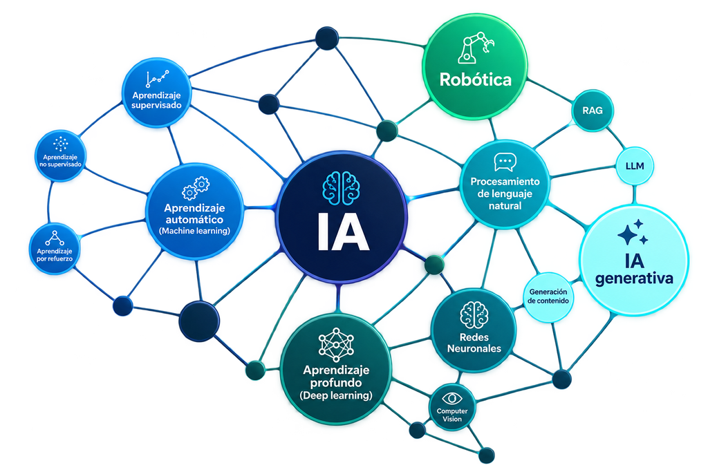

La rama que hoy domina (y en la que nos enfocamos), es la **IA generativa**

## Pero antes… un ejemplo

Los productos Cherryway 4 y Cherryscan de MAF RODA estan diseñados para clasificar la fruta por, forma, color y tambien para detectar anomalías en la fruta.

[figure not shown]

El sistema que combina algoritmos de clasificación (aprendizaje supervisado) y detección de anomalías (aprendizaje no supervisado). Toda esta tecnología está montada sobre una estructura de redes neuronales (neural networks), lo que le da a la máquina la ventaja de analizar la fruta a gran velocidad, ‘entendiendo’ si una variación en la piel es solo un tono natural o un defecto real.

## Qué distingue a la IA generativa?

Los **Modelos generativos**, producen contenido nuevo — texto, imágenes, audio, código — a partir de una instrucción. Los LLM pertenecen a esta familia.

> A diferencia de un modelo predictivo clásico, que devuelve un valor o una categoría, un modelo generativo devuelve texto, imágenes u otros contenidos que construye a medida.

Internamente lo hace armando la respuesta pieza por pieza, eligiendo en cada paso la continuación más plausible de lo que ya lleva escrito, a partir de todo lo que vio durante su *entrenamiento*.

## Conociendo a la IA generativa

¿pero qué significa ‘predecir la proxima palabra más probable’? ¿qué entendemos por ‘entrenamiento’?

### Modelo de inicio aleatoreo

Se inicia con un modelo de lenguaje natual (NLP) muy básico que ante consultas arroja un resultado aleatoreo (disparates).

[figure not shown]

### Pre-entrenamiento

El modelo inicial se entrena sobre un corpus ENORME (material científico correcto, material divulgativo con errores, opiniones de foros, textos contradictorios entre sí, textos con sesgos culturales, comerciales o ideológicos).

[figure not shown]

> NO ES UNA BASE DE DATOS. Una base de datos almacena información, la oración se guarda tal cual y la consulta la recupera idéntica. Un LLM, en cambio, NO almacena las oraciones que vio: las usa durante el entrenamiento para ajustar miles de millones de parámetros numéricos de modo que el modelo se vuelva más probable de producir textos parecidos a los que leyó.

### Instrucción de afinamiento

Al modelo se le otorgan instrucciones para convertirlo en una herramienta de conversación. “No respondas temas potencialmente peligrosos”, “Se amable”, “Responde en un margen que invite al usuario a hacer más preguntas”.

[figure not shown]

Estas instrucciones vienen dadas por la compañía desarrolladora, no se pueden alterar y estan ocultas al usuario.

### Instrucción de preferencias

Estas instrucciones son dadas directamente por el usuario.

[figure not shown]

Muchos modelos pueden desplegar opciones de respuestas el usuario escoge como le gusta que le respondan y el modelo actualiza sus parametros para responderle a ese usuario en particular.

### Afinamiento de razocinio

[figure not shown]

Esto es especialmente relevante para tareas matemáticas o lógicas y se basa en la idea del aprendizaje por refuerzo (¡Machine learning!), es decir, prueba y error.

## Consecuencias de los LLM

De la arquitectura misma del LLM se desprenden tres consecuencias que atraviesan todo el uso práctico de estas herramientas:

1. **No consulta una base de datos de verdades.**
2. **No dispone de un mecanismo para reconocer sus propios límites.**
3. **La herramienta alucina**

> Por lo tanto **La IA generativa propone; quien la usa valida.**

## Dos formas de acceder al mismo modelo

Detrás de las herramientas conocidas hay un modelo. A ese modelo se le puede acceder de dos maneras:

- A través de una **ventana de chat**, que es la vía habitual cuando una persona conversa con la herramienta.
- A través de una **API**, que es la vía por la que un programa envía instrucciones al modelo sin intervención humana directa.

## Usos frecuentes

1. Creación de imágenes/videos.
2. Investigación: ahí donde usabamos google, ahora se utiliza la IA generativa (Gemini, Meta, Perplexity).
3. Creación de reportes.
4. Creación de código para el análisis de datos, desarrollo de aplicaciones, creación de paginas web, etc.

## Criticas frecuentes

1. Uso del agua y tierra.
2. Demanda energética.
3. Uso ético (datos personales, carrera armamentista, sensibilidad de los usuarios).
4. Limitada capacidad de regulación.
5. Caja negra de entrenamiento.